### Построение графика наблюдаемых и модельных значений зависимой переменной

Построим график модельных и фактических значений (предсказанных и истинных) зависимой переменной: Необходимо удалить выбросы у функции price, иначе код не будет работать

```r
max(df_new$price)
```

```
## [1] 28248
```

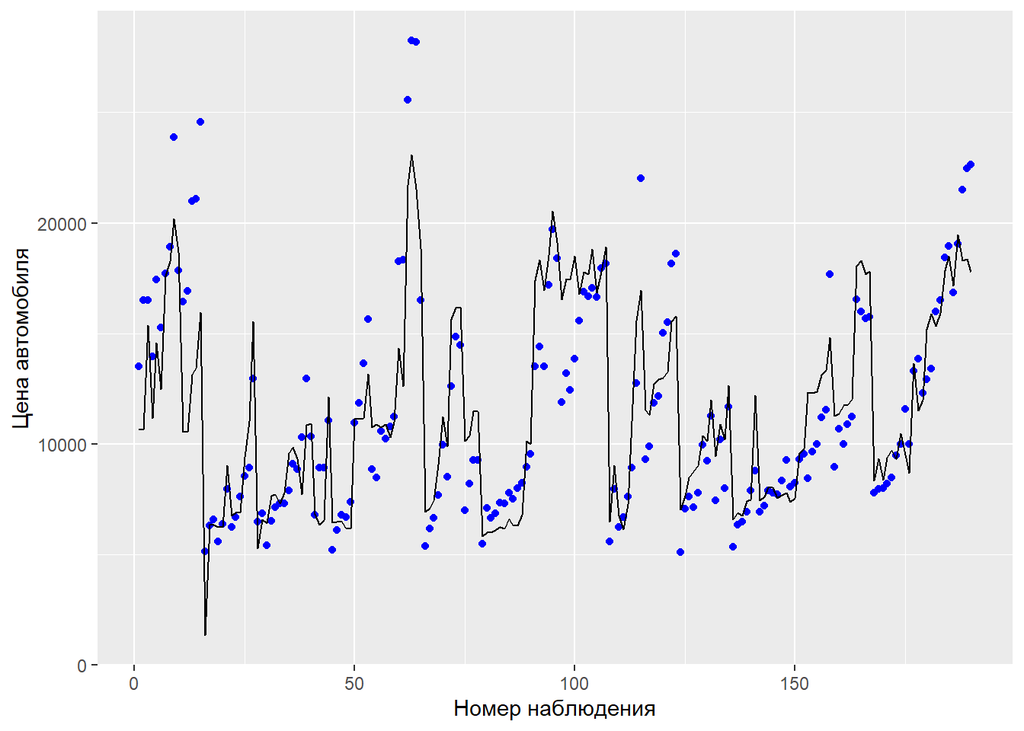

```r
df_new$pred <- predict(lm5)
ggplot(df_new, aes(x = seq(1, nrow(df_new), 1), y = df_new$price)) +
  geom_point(color = "blue") +
  geom_line(aes(x = seq(1, nrow(df_new), 1), y = df_new$pred)) +
  labs(x = "Номер наблюдения", y = "Цена автомобиля")
```

На данном графике мы видим, что, несмотря на то, что мы получили высокое значение коэффициента детерминации, достаточно большое количество истинных значений отклоняются от предсказанных моделью. Максимальное предсказанное значение меньше 25000, в то время как максимальное несколько истинных значений превышают 25000.

Интервальные оценки коэффициентов регрессии:

```r
pander(coefci(lm5))
```

|  | 2.5 % | 97.5 % |
| --- | --- | --- |
| **(Intercept)** | -71512 | -32585 |
| **curbweight** | 3.604 | 7.859 |
| **horsepower** | 20.63 | 58.87 |
| **carwidth** | 360.2 | 1132 |
| **carlength** | -153.1 | -0.2144 |
| **wheelbase** | -48.01 | 246.4 |

Все интервальные оценки коэффициентов регрессии не содержат 0, за исключением оценки коэффициента при регрессоре wheelbase. Это объясняется тем, что этот коэффициент незначим. Такое вывод мы уже получали выше.

Визуализация интервальных оценок коэффициентов регрессии:

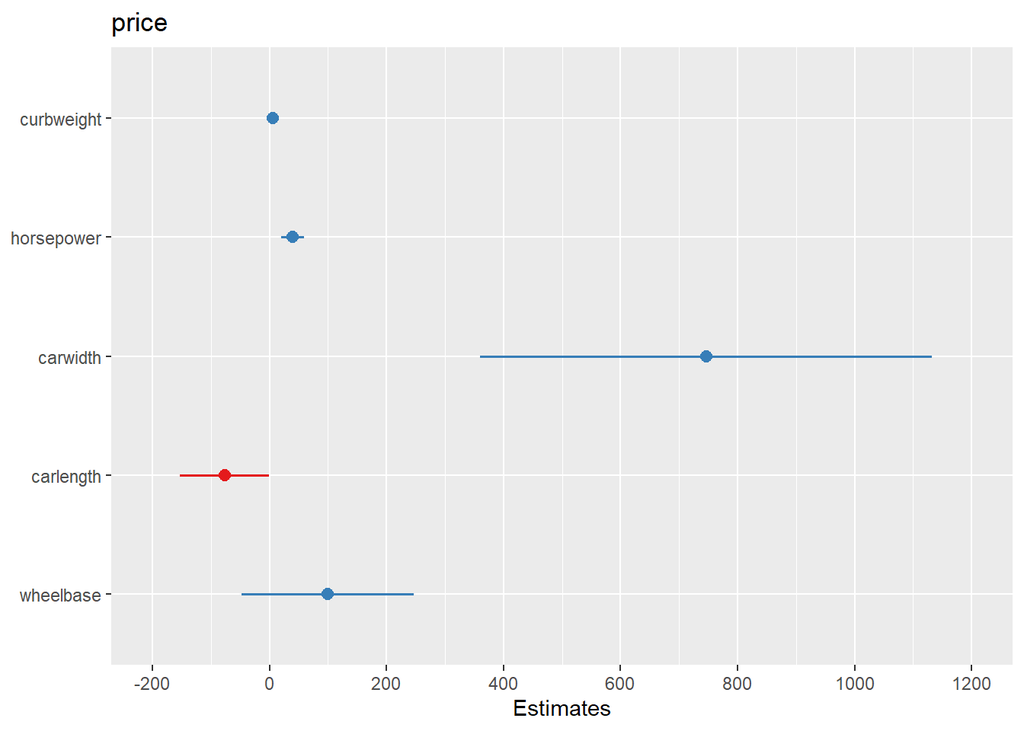

```r
plot_model(lm5, ci.lvl = 0.95)
```